# Lista de Exercícios 2 - ADAR/UFSM

Gabriel Welter Hartmann

2022-01-21

Carregando as bibliotecas que serão usadas

```r
library(dplyr)
```

## Exercícios

1. Crie um vetor com os valores de $e^x \: cos(x)$ para os valores de $x = ( 3, \: 3.1, \: 3.2, \:..., \: 6 )$.

```r
(x <- seq(from = 3, to = 6, by = 0.1))
 [1] 3.0 3.1 3.2 3.3 3.4 3.5 3.6 3.7 3.8 3.9 4.0 4.1 4.2 4.3 4.4 4.5 4.6 4.7 4.8
[20] 4.9 5.0 5.1 5.2 5.3 5.4 5.5 5.6 5.7 5.8 5.9 6.0

e_x <-exp(x) * cos(x)
e_x
 [1] -19.884531 -22.178753 -24.490697 -26.773182 -28.969238 -31.011186
 [7] -32.819775 -34.303360 -35.357194 -35.862834 -35.687732 -34.685042
[13] -32.693695 -29.538816 -25.032529 -18.975233 -11.157417  -1.362099
[19]  10.632038  25.046705  42.099201  61.996630  84.929067 111.061586
[25] 140.525075 173.405776 209.733494 249.468441 292.486707 338.564378
[31] 387.360340
```

2. Crie os seguintes vetores.
   1. $(0.1^3 \times 0.2^1, \: 0.1^6 \times 0.2^4, \: ..., \: 0.1^{36} \times$ $\:0.2^{34})$

```r
exp1 <- seq(from = 3, to = 36, by = 3)
exp2 <- seq(from = 1, to = 34, by = 3)
vetor_2a <- 0.1^(exp1) * 0.2^(exp2)
vetor_2a
 [1] 2.000000e-04 1.600000e-09 1.280000e-14 1.024000e-19 8.192000e-25
 [6] 6.553600e-30 5.242880e-35 4.194304e-40 3.355443e-45 2.684355e-50
[11] 2.147484e-55 1.717987e-60
```

2. $\left(2, \: \frac{2^2}{2}, \: \frac{2^3}{3}, \: ..., \: \frac{2^{25}}{25} \right)$

```r
seq_aux <- seq(from = 1, to = 25, by = 1)
vetor_2b <- (2^(seq_aux))/seq_aux
vetor_2b
 [1] 2.000000e+00 2.000000e+00 2.666667e+00 4.000000e+00 6.400000e+00
 [6] 1.066667e+01 1.828571e+01 3.200000e+01 5.688889e+01 1.024000e+02
[11] 1.861818e+02 3.413333e+02 6.301538e+02 1.170286e+03 2.184533e+03
[16] 4.096000e+03 7.710118e+03 1.456356e+04 2.759411e+04 5.242880e+04
[21] 9.986438e+04 1.906502e+05 3.647221e+05 6.990507e+05 1.342177e+06
```

3. Reproduza a criação do vetor dias da semana (`dds`) mostrado abaixo.

```
domingo segunda terca quarta quinta sexta sabado
      1       2     3      4      5     6      7
```

```r
dds <- c(
         domingo = 1,
         segunda = 2,
         terca = 3,
         quarta = 4,
         quinta = 5,
         sexta = 6,
         sabado = 7
)

dds
domingo segunda   terca  quarta  quinta   sexta  sabado
      1       2       3       4       5       6       7
```

4. Interprete o resultado da seguinte operação:

```
dds_nums <- c(
  5L, 2L, 5L, 2L, 7L, 7L, 2L,
  6L, 6L, 3L, 7L, 1L, 2L, 2L,
  5L, 7L, 3L, 2L, 6L, 4L, 1L
)
names(dds)[dds_nums]
```

```r
dds_nums <- c(
  5L, 2L, 5L, 2L, 7L, 7L, 2L,
  6L, 6L, 3L, 7L, 1L, 2L, 2L,
  5L, 7L, 3L, 2L, 6L, 4L, 1L
)
names(dds)[dds_nums]
 [1] "quinta"  "segunda" "quinta"  "segunda" "sabado"  "sabado"  "segunda"
 [8] "sexta"   "sexta"   "terca"   "sabado"  "domingo" "segunda" "segunda"
[15] "quinta"  "sabado"  "terca"   "segunda" "sexta"   "quarta"  "domingo"
```

A linha de atribuição a `dds_nums` cria um vetor de inteiros (no qual eu não identifiquei uma sequência lógica) com um `range` igual ao comprimento de`dds`. Assim a linha `names(dds)[dds_nums]` serve para exibir os nomes do vetor `dds` na posição apontada pelos elementos de `dds_nums`, e como cada posição do vetor `dds` é nomeada com o respectivo dia da semana, são exibidos os dias da semana de acordo com a sequência de `dds_nums`.

5. a.Escreva o código necessário para determinar o vetor lógico indicando quais números são pares na sequência de valores 85, 79, 70, 6, 32, 8, 17, 93, 81, 76.

```r
vetor_5a <- c(85, 79, 70, 6, 32, 8, 17, 93, 81, 76)
vetor_par_5a <- (vetor_5a %% 2 == 0)
vetor_par_5a
 [1] FALSE FALSE  TRUE  TRUE  TRUE  TRUE FALSE FALSE FALSE  TRUE
```

2. Calcule o total de números ímpares.

```r
quant_impar <- sum(vetor_5a %% 2 != 0)
quant_impar
[1] 5
```

6. Para um ano ser bissexto, ele deve ser:
- divisível por 4(a divisão é eata com resto igual a zero).
- não pode ser divisível por 100 (a divisão não é exata, ou seja, o resto é diferente de zero).
- pode ser que seja divisível por 4000: caso seja divisível por 400, a divisão deve ser exata, deixando oresto igual a zero.

Com os critérios definidos acima, construa o código para:

1. Verificar se os anos 1894, 1947, 1901, 1992, 1925, 2014, 1993, 1996, 1984, 1897, 2100, 2300 são bissextos.

```r
anos <- c(1894, 1947, 1901, 1992, 1925, 2014, 1993, 1996, 1984, 1897, 2100, 2300)

ano_bissexto <- (anos %% 4 == 0 & anos %% 100 != 0) | (anos %% 4 == 0 & anos %% 400 == 0 )

ano_bissexto
 [1] FALSE FALSE FALSE  TRUE FALSE FALSE FALSE  TRUE  TRUE FALSE FALSE FALSE
```

2. Mostre quais anos são bissextos.

```r
anos[ano_bissexto]
[1] 1992 1996 1984
```

3. Usando o código para verificar se o ano é bissexto, gere um vetor nomeado `ndias` com o número de dias do ano para os anos do item (a).

```r
ndias <- ifelse(
                test = ano_bissexto,
                yes = 366,
                no = 365
)
ndias
 [1] 365 365 365 366 365 365 365 366 366 365 365 365
```

4. Programe como obter o total de anos com 366 dias.

```r
tot_anos_bissexto <- sum(ano_bissexto)
tot_anos_bissexto
[1] 3

#ou

tot_anos_bissexto <- sum(ndias == 366)
tot_anos_bissexto
[1] 3
```

7. Quais códigos para gerar os seguintes dados:
1. `[1] -30 0 5 10 15 20 30`

```r
vetor_7a <- c(
              -30,
              seq(from = 0, to = 20, by = 5),
              30
)
vetor_7a
[1] -30   0   5  10  15  20  30
```

2. `[1] 1.0 0.8 0.6 0.4 0.2 0.0`

```r
vetor_7b <- seq(from = 1.0, to = 0.0, by = -0.2)
vetor_7b
[1] 1.0 0.8 0.6 0.4 0.2 0.0
```

```
[1] -3.1415927 -2.4434610 -1.7453293 -1.0471976 -0.3490659  0.3490659
[7]  1.0471976  1.7453293  2.4434610  3.1415927
```

```r
vetor_7c <- seq(from = -pi, to = pi, length.out = 10)
vetor_7c
 [1] -3.1415927 -2.4434610 -1.7453293 -1.0471976 -0.3490659  0.3490659
 [7]  1.0471976  1.7453293  2.4434610  3.1415927
```

```
[1] -1 -1  0  0  0  1  1  1  1  2  2  2  2  2  3  3  3  3  3  3  4  4  4
[24]  4  4  4  4  5  5  5  5  5  5  5  5
```

```r
vetor_7d <- rep(x = -1:5, times = 2:8)
vetor_7d
 [1] -1 -1  0  0  0  1  1  1  1  2  2  2  2  2  3  3  3  3  3  3  4  4  4  4  4
[26]  4  4  5  5  5  5  5  5  5  5
```

```
[1] 5 5 5 5 5 4 4 4 4 3 3 3 2 2 1 2 2 3 3 3 4 4 4 4 5 5 5 5 5
```

```r
vetor_7e <- rep(x = c(5:1,2:5), times = c(5:1,2:5))
vetor_7e
 [1] 5 5 5 5 5 4 4 4 4 3 3 3 2 2 1 2 2 3 3 3 4 4 4 4 5 5 5 5 5
```

8. Usando o mesmo código para solução em todos os itens abaixo, obtenha as seguintes sequências usando os vetores fornecidos.
1. v3 = (11, 0.25, 7, 2)

```
[1] 1 2 3 4
```

Computando o vetor fornecido e atribuindo-o ao vetor da solução padrão.

```r
vetor_8 <- v3 <- c(11, 0.25, 7, 2)
```

Aplicando o código padrão.

```r
seq(from = 1, to = length(vetor_8), length.out = length(vetor_8))
[1] 1 2 3 4
```

2. v2 = (11, 0.25)

```
[1] 1 2
```

Computando o vetor fornecido e atribuindo-o ao vetor da solução padrão.

```r
vetor_8 <- v2 <- c(11, 0.25)
```

Aplicando o código padrão.

```r
seq(from = 1, to = length(vetor_8), length.out = length(vetor_8))
[1] 1 2
```

3. v1 = (11)

```
[1] 1
```

Computando o vetor fornecido e atribuindo-o ao vetor da solução padrão.

```r
vetor_8 <- v1 <- c(11)
```

Aplicando o código padrão.

```r
seq(from = 1, to = length(vetor_8), length.out = length(vetor_8))
[1] 1
```

4. v0 = ()

```
integer(0)
```

Computando o vetor fornecido e atribuindo-o ao vetor da solução padrão.

```r
vetor_8 <- v0 <- c()
```

Aplicando o código padrão.

```r
seq(from = 1, to = length(vetor_8), length.out = length(vetor_8))
integer(0)
```

9. Considere os seguintes dados horários de temperatura do ar $(T_{ar})$ registrados em duas estações meteorológicas, entre as 0 e 23 horas de um dado dia.

```r
tar_est1 <- c(
  14.92, 14.61, 14.32, 14.07, 13.84, 13.65, 13.56, 13.97, 15.08,
  16.5, 17.88, 19.08, 20.02, 20.66, 21.01, 21.05, 20.76, 20.05,
  18.77, 17.51, 16.67, 16.11, 15.66, 15.27
)
tar_est2 <- c(
  13.13, 13.01, 12.93, 12.87, 12.82, 12.81, 13.2, 14.22, 15.77,
  17.49, 19.2, 20.57, 21.49, 22.01, 22.03, 21.71, 20.84, 18.77,
  16.54, 15.13, 14.34, 13.81, 13.49, 13.28
)
```

> Dica: Faça um gráfico para visualizar as temperaturas das duas estações. Isso facilitará a solução.

Seguindo a dica dada:

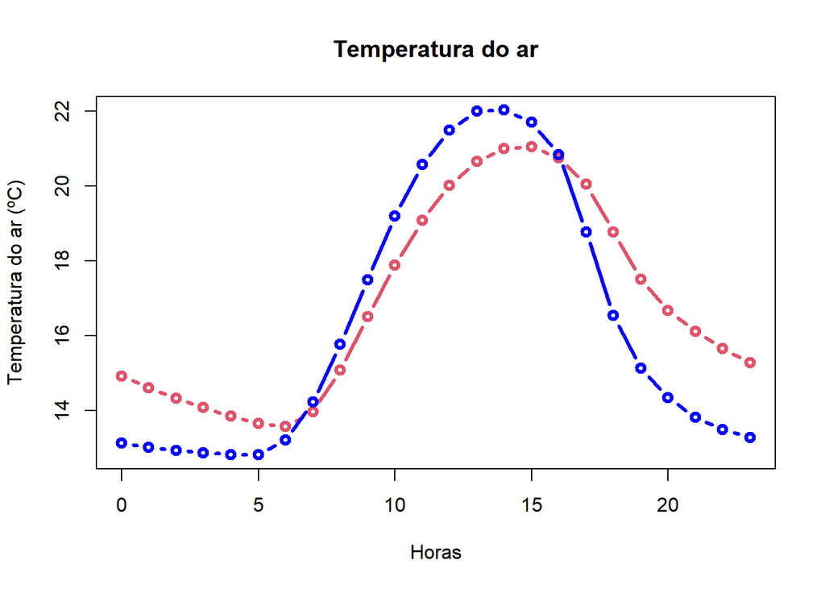

```r
length(tar_est1)
[1] 24
length(tar_est2)
[1] 24

#verificando o tamanho dos vetores

horas <- seq(0, 23)

plot(
     x = horas,
     y = tar_est1,
     xlab = "Horas",
     ylab = "Temperatura do ar (ºC)",
     main = "Temperatura do ar",
     type = "b",
     lwd = 3,
     col = 2,
     ylim = range(c(tar_est1,tar_est2))
)

lines(
      x = horas,
      y = tar_est2,
      col = "blue",
      lwd = 3,
      type = "b"
)
```

Sendo a linha vermelha `tar_est1`, e a linha azul `tar_est2`.

1. Determine a média diária de $T_{ar}$ das duas estações arredondando para uma casa decimal. Salve a média de cada estação nas variáveis `tmed_est1` e `tmed_est2`.

```r
tmed_est1 <- round(x = mean(tar_est1), digits = 1)
tmed_est2 <- round(x = mean(tar_est2), digits = 1)
tmed_est1
[1] 16.9
tmed_est2
[1] 16.3
```

2. Utilizando as variáveis do item anterior, verifique usando comparação lógica, em qual estação o ambiente é mais quente?

```r
tmed_est1 == tmed_est2
[1] FALSE

#Os valores não são iguais

est_quente <- ifelse(
                     test = tmed_est1 > tmed_est2,
                     yes = "O ambiente da estação 1 é mais quente",
                     no = "O ambiente da estação 2 é mais quente"
)
est_quente
[1] "O ambiente da estação 1 é mais quente"
```

3. Obtenha a 3ª maior temperatura do dia em cada estação.

```r
maxtemp3_est1 <- sort(x = tar_est1, decreasing = TRUE)[3]
maxtemp3_est2 <- sort(x = tar_est2, decreasing = TRUE)[3]
maxtemp3_est1
[1] 20.76
maxtemp3_est2
[1] 21.71
```

4. Calcule a amplitude térmica diária ($ATD = T_{máx}-T_{min}$, onde $T_{máx}$: temperatura máxima diária e $T_{min}$: temperatura mínima diária) das estações 1 e 2, arredondando para uma casa decimal. Salve os resultados nas variáveis `atd_est1` e `atd_est2`.

```r
atd_est1 <- round(max(tar_est1)-min(tar_est1), digits = 1)
atd_est2 <- round(max(tar_est2)-min(tar_est2), digits = 1)
atd_est1
[1] 7.5
atd_est2
[1] 9.2
```

5. Qual o horário de ocorrência das temperaturas máximas e mínimas em cada estação? Salve os resultados nas variáveis `hmax_est{i}` e `hmin_est{i}`, com $i = 1, 2$.

```r
hmax_est1 <- horas[which(max(tar_est1) == tar_est1)]
hmax_est2 <- horas[which(max(tar_est2) == tar_est2)]
hmin_est1 <- horas[which(min(tar_est1) == tar_est1)]
hmin_est2 <- horas[which(min(tar_est2) == tar_est2)]
hmax_est1
[1] 15
hmax_est2
[1] 14
hmin_est1
[1] 6
hmin_est2
[1] 5
```

6. Quando `tar_est2` é maior que `tar_est1` qual a maior diferença absoluta de temperatura entre as duas estações?

```r
vetor_max_diff <- abs(tar_est2[which(tar_est2 > tar_est1)]) -
  abs(tar_est1[which(tar_est2 > tar_est1)])
max_diff <- max(vetor_max_diff)
max_diff
[1] 1.49
```

7. Qual a hora correspondente à ocorrência daquela maior diferença absoluta de temperatura obtida no item anterior?

```r
hora_max_diff <- horas[which(tar_est2 > tar_est1 & (abs(tar_est2) -
  abs(tar_est1)) == max_diff)]
hora_max_diff
[1] 11
```

8. O horário do pôr do sol ser estimado a partir da $T_{ar}$. Para o período após o horário de ocorrência da $T_{máx}$ determina-se em qual hora ocorre a maior queda de $T_{ar}$ em relação a hora anterior. Estime o horário do pôr do sol para as duas estações (`hps_est{i}`).

```r
tar_apos_tmax_est1 <- tar_est1
tar_apos_tmax_est1[1:hmax_est1] <- NA

diff_apos_tmax_est1 <- c(NA, diff(tar_apos_tmax_est1))
aux1 <- which(diff_apos_tmax_est1 == min(diff_apos_tmax_est1, na.rm = TRUE))
hps_est1 <- horas[aux1]
hps_est1
[1] 18

tar_apos_tmax_est2 <- tar_est2
tar_apos_tmax_est2[1:hmax_est2] <- NA

diff_apos_tmax_est2 <- c(NA, diff(tar_apos_tmax_est2))
aux2 <- which(diff_apos_tmax_est2 == min(diff_apos_tmax_est2, na.rm = TRUE))
hps_est2 <- horas[aux2]
hps_est2
[1] 18
```

1. Em quais horas as temperaturas das duas estações estão mais próximas uma da outra, ou seja com menos de 0,5°C de diferença ?

```r
horas_prox <- horas[which(abs(tar_est1 - tar_est2) < 0.5)]
horas_prox
[1]  6  7 16
```

10. Calcule a temperatura média diária usando os seguintes métodos para a estação 2.

$T_{med1} = \frac{T_{max}+T_{min}}{2}$, salvando em uma variável `tar_met1`.

$T_{med2}= \frac{T_{max}+T_{min}+T_{9}+2T_{21}}{5}$, salvando em uma variável `tar_met2`.

```r
tar_met1 <- (max(tar_est2) + min(tar_est2)) / 2
tar_met1
[1] 17.42

tar_met2 <- (max(tar_est2) + min(tar_est2) + tar_est2[which(horas == 9)] +
  tar_est2[which(horas == 21)] * 2) / 5
tar_met2
[1] 15.99

tar_met3 <- (tar_est2[which(horas == 7)] + tar_est2[which(horas == 14)] +
  tar_est2[which(horas == 9)] * 2) / 4
tar_met3
[1] 17.8075
```

11. Compare este resultado com aqueles obtidos no item a. Qual é melhor?

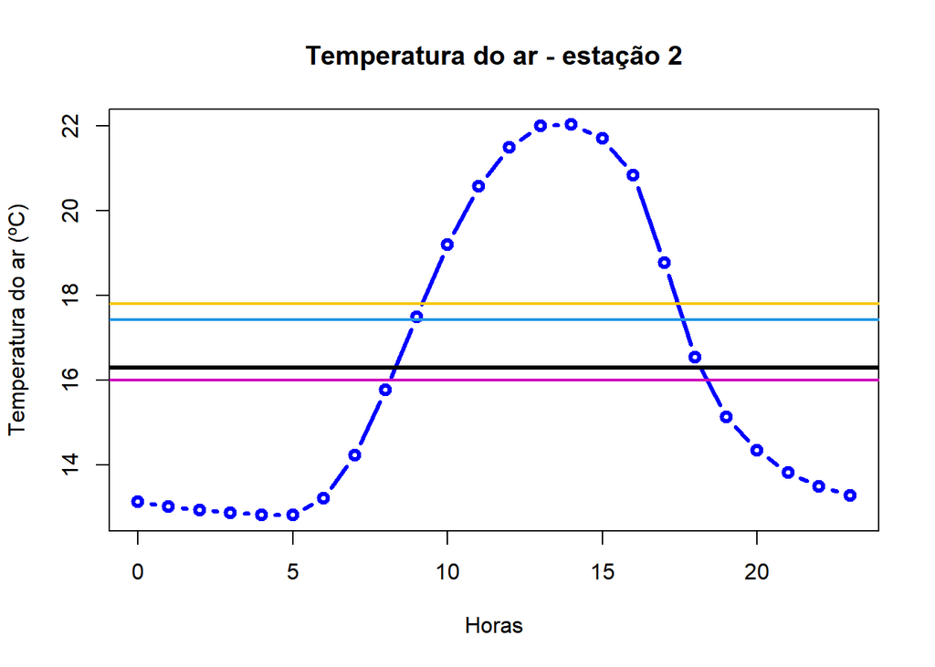

```r
plot(
     x = horas,
     y = tar_est2,
     xlab = "Horas",
     ylab = "Temperatura do ar (ºC)",
     main = "Temperatura do ar - estação 2",
     type = "b",
     lwd = 3,
     col = "blue",
     ylim = range(tar_est2)
)

abline(h = tmed_est2, col = 1, lwd = 3)

abline(h = tar_met1, col = 4, lwd = 2)
abline(h = tar_met2, col = 6, lwd = 2)
abline(h = tar_met3, col = 7, lwd = 2)
```

- `tar_met1` em azul claro.
- `tar_met2` em rosa.
- `tar_met3` em amarelo.

O melhor é `tmed_est2` (em preto), da questão 1, por levar em conta mais valores.

10. Calcule a temperatura do ar horária usando o **modelo de onda** para representação do ciclo diário da temperatura do ar, descrito pelas seguintes equações:

$$\left\{ \begin{matrix}
h_{T_{min}} \leq h \leq h_{T_{max}} , \; T_{calc} = \overline{T} - A\cos(arg) \\
\text{demais horas}, \; T_{calc} = \overline{T} + A\cos(arg)
\end{matrix}\right.$$

onde:

$$\overline{T} = \left(\frac{T_{máx}+T_{min}}{2} \right)$$

e

$$A =\left(\frac{T_{máx}-T_{min}}{2} \right)$$

O argumento do cosseno $(arg)$ é definido por:

$$\left\{ \begin{matrix}
h \le h_{T_{min}}, \; arg = \pi\left( \frac{h+10}{10+h_{T_{min}}} \right) \\
h_{T_{min}} \leq h < h_{T_{max}}, \; arg = \pi \left( \frac{h - h_{T_{min}}}{14
- h_{T_{min}}} \right) \\
h > h_{T_{max}}, \; arg = \pi \left( \frac{14-h}{10+h_{T_{min}}} \right)
\end{matrix} \right.$$

1. Aplique o método acima para a estação 1 e 2 substituindo os valores de $T_{max}$, $T_{min}$, $h_{T_{max}}$ e $h_{T_{min}}$, adequadamente.

```r
t_barra_est1 <- (max(tar_est1) + min(tar_est1)) / 2
a_upper_est1 <- (max(tar_est1) - min(tar_est1)) / 2

arg1_est1 <- pi*((horas[1:hmin_est1] + 10) / (10 + hmin_est1))

arg2_est1 <- pi*((horas[(hmin_est1+1):hmax_est1] - hmin_est1) / (14 - hmin_est1))

arg3_est1 <- pi*((14 - horas[(hmax_est1+1):length(horas)]) / (10 + hmin_est1))

tar_calc_est1 <- rep(x = NA, times = length(tar_est1)) #inicializa o vetor da
#temperatura calculada sem valor algum, mas com o mesmo tamanho de tar_est1

tar_calc_est1[1:hmin_est1] <- t_barra_est1 + a_upper_est1 * cos(arg1_est1)
tar_calc_est1[(hmin_est1 + 1):hmax_est1] <- t_barra_est1 - a_upper_est1 *
  cos(arg2_est1)
tar_calc_est1[(hmax_est1 + 1):length(tar_calc_est1)] <- t_barra_est1 +
  a_upper_est1 * cos(arg3_est1)

t_barra_est2 <- (max(tar_est2) + min(tar_est2)) / 2
a_upper_est2 <- (max(tar_est2) - min(tar_est2)) / 2

arg1_est2 <- pi*((horas[1:hmin_est2] + 10) / (10 + hmin_est2))

arg2_est2 <- pi*((horas[(hmin_est2+1):hmax_est2] - hmin_est2) / (14 - hmin_est2))

arg3_est2 <- pi*((14 - horas[(hmax_est2+1):length(horas)]) / (10 + hmin_est2))

tar_calc_est2 <- rep(x = NA, times = length(tar_est2)) #inicializa o vetor da
#temperatura calculada sem valor algum, mas com o mesmo tamanho de tar_est2

tar_calc_est2[1:hmin_est2] <- t_barra_est2 + a_upper_est2 * cos(arg1_est2)
tar_calc_est2[(hmin_est2 + 1):hmax_est2] <- t_barra_est2 - a_upper_est2 *
  cos(arg2_est2)
tar_calc_est2[(hmax_est2 + 1):length(tar_calc_est2)] <- t_barra_est2 +
  a_upper_est2 * cos(arg3_est2)
```

Gerando o gráfico da temperatura calculada(linha) em comparação com a observada(pontos):

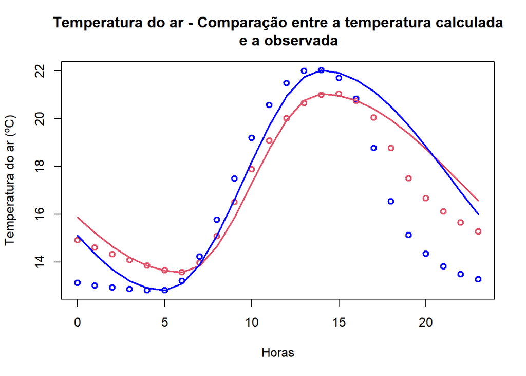

```r
plot(
     x = horas,
     y = tar_est1,
     xlab = "Horas",
     ylab = "Temperatura do ar (ºC)",
     main = "Temperatura do ar - Comparação entre a temperatura calculada
     e a observada",
     type = "p",
     lwd = 2,
     col = 2,
     ylim = range(c(tar_est1,tar_est2))
)
par(lheight = 2)

lines(
      x = horas,
      y = tar_est2,
      col = "blue",
      lwd = 2,
      type = "p"
)

lines(
      x = horas,
      y = tar_calc_est1,
      col = 2,
      lwd = 2,
      type = "l"
)

lines(
      x = horas,
      y = tar_calc_est2,
      col = "blue",
      lwd = 2,
      type = "l"
)
```

Sendo a linha vermelha a temperatura calculada da **estação 1**, e os pontos vermelhos `tar_est1`. E os equivalentes em azul para a **estação 2**.

2. Calcule o RMSE nos dois casos.

$$RMSE = \sqrt{\frac{1}{n}\sum^{n}_{i=1}(T_{calc}-T_{obs})^2}$$

```r
rmse_est1 <- sqrt(sum((tar_calc_est1 - tar_est1)^2) / length(tar_est1))

rmse_est1
[1] 0.9109839

rmse_est2 <- sqrt(sum((tar_calc_est2 - tar_est2)^2) / length(tar_est2))

rmse_est2
[1] 2.133115
```

3. Calcule a correlação ($r$) nos dois casos. A barra representa a média aritmética. Confira seu resultado com a saída da função `cor(tar_obs, tar_calc)`.

```r
corr_est1 <- sum((tar_est1 - mean(tar_est1)) * (tar_calc_est1 - mean(tar_calc_est1))) /
  sqrt(sum(((tar_est1 - mean(tar_est1))^2)) * sum((tar_calc_est1 - mean(tar_calc_est1))^2))

corr_est1
[1] 0.9534668

corr_est2 <- sum((tar_est2 - mean(tar_est2)) * (tar_calc_est2 - mean(tar_calc_est2))) /
  sqrt(sum(((tar_est2 - mean(tar_est2))^2)) * sum((tar_calc_est2 - mean(tar_calc_est2))^2))

corr_est2
[1] 0.8546298
```

Conferindo o resultado com a saída da função `cor(tar_obs, tar_calc)`

```r
all.equal(
          target = corr_est1,
          current = cor(tar_est1, tar_calc_est1)
)
[1] TRUE

all.equal(
          target = corr_est2,
          current = cor(tar_est2, tar_calc_est2)
)
[1] TRUE
```

Verifica-se que os resultados são idênticos, guardada certa precisão.

11. Os dados abaixo são de precipitação horária de um evento severo ocorrido em 03/12/2012 em Santa Maria-RS.

```r
horas_q11 <- 9:21
prech_q11 <- c(0.0, 0.0, 0.0, 0.0, 0.0, 0.0, 0.0, 21.4, 41.2, 2.6, 1.0, 0.4,
  0.0)
```

1. Como seria o código para determinar a soma cumulativa da precipitação horária? Salve o resultado em um vetor chamado `prec_acum`. Interprete o resultado de `c(NA, diff(prec_acum))`.

```r
prec_acum <- cumsum(prech_q11)
prec_acum
 [1]  0.0  0.0  0.0  0.0  0.0  0.0  0.0 21.4 62.6 65.2 66.2 66.6 66.6

c(NA, diff(prec_acum))
 [1]   NA  0.0  0.0  0.0  0.0  0.0  0.0 21.4 41.2  2.6  1.0  0.4  0.0
```

A função `diff()` calcula e diferença entre elementos consecutivos de um vetor, fazendo a subtração de cada componente (partindo do segundo) pelo seu anterior. Desse modo, o vetor resultante da aplicação de `diff()` tem uma posição a menos que o vetor passado como argumento. Fazer a diferença do resultado de uma soma cumulativa nos retorna o vetor original, passado como argumento na função `cumsum()`. Assim, o resultado de`c(NA, diff(prec_acum))` é o vetor da precipitação horária, mas com `NA` no lugar do valor da primeira posição.

2. Mostre o código para encontrar o horário de ocorrência da precipitação máxima.

```r
hmax_q11 <- horas_q11[which(prech_q11 == max(prech_q11))]
hmax_q11
[1] 17
```

3. Mostre o código para obter a hora de início e fim do evento de precipitação severa. Qual a duração do evento?

Partindo do princípio que só é contemplado um evento de precipitação durante a série temporal dada (como é possível de observar que ocorre).

```r
prech_logic <- prech_q11 > 0

hora_ini <- horas_q11[which(cumsum(prech_logic) == 1)[1]]
hora_ini
[1] 16

hora_fim <- horas_q11[which.max(cumsum(prech_logic))]
hora_fim
[1] 20

duracao <- hora_fim - hora_ini + 1
duracao
[1] 5
```

Agora se formos considerar a precipitação severa apenas quando a medição for maior que 20 mm.

```r
prech_logic2 <- prech_q11 > 20.0

hora_ini2 <- horas_q11[which(cumsum(prech_logic2) == 1)[1]]
hora_ini2
[1] 16

hora_fim2 <- horas_q11[which.max(cumsum(prech_logic2))[1]]
hora_fim2
[1] 17

duracao2 <- hora_fim2 - hora_ini2 + 1
duracao2
[1] 2
```

Outra forma de calcular.

```r
limiar_cond <- 20.0

ocorr_cond <- as.integer(prech_q11 > limiar_cond)

index_ini_cond <- which(lag(ocorr_cond) - ocorr_cond < 0)

index_prim_cond <- ifelse(
  test = ocorr_cond[1] == 1,
  yes = 1,
  no = 0
)
index_ini_cond <- c(index_prim_cond, index_ini_cond)

index_fim_cond <- which(lead(ocorr_cond) - ocorr_cond < 0)

index_ult_cond <- ifelse(
  test = ocorr_cond[length(ocorr_cond)] == 1,
  yes = length(ocorr_cond),
  no = 0
)
index_fim_cond <- c(index_fim_cond, index_ult_cond)

#hora de início
horas_q11[index_ini_cond]
[1] 16

#hora de fim
horas_q11[index_fim_cond]
[1] 17


duracao_cond <- horas_q11[index_fim_cond] - horas_q11[index_ini_cond] + 1

#duração
duracao_cond
[1] 2
```

4. Qual foi a precipitação total do evento? Quanto da precipitação total do evento, em %, ocorreu até às 17 h?

```r
prec_tot <- sum(prech_q11[which(horas_q11 == hora_ini):which(horas_q11 == hora_fim)])
prec_tot
[1] 66.6

percent_17h <- sum(prech_q11[which(horas_q11 == hora_ini):which(horas_q11 == 17)]) /
  prec_tot * 100
percent_17h
[1] 93.99399
```

Para o segundo caso considerado (em que o evento de precipitação severa só é considerando enquanto a precipitação horária for maior que 20 mm).

```r
prec_tot2 <- sum(prech_q11[which(horas_q11 == hora_ini2):which(horas_q11 == hora_fim2)])
prec_tot2
[1] 62.6

percent_17h_2 <- sum(prech_q11[which(horas_q11 == hora_ini2):which(horas_q11 == 17)]) /
  prec_tot2 * 100
percent_17h_2
[1] 100
```

12. Considere o vetor `x` definido pelos números descritos abaixo. Mostre como encontrar o primeiro número positivo localizado após o último número negativo. Por exemplo, seja o vetor `z` definido pelos valores (11, 10, 15, 2, 6, -15, -10, -22, -8, 5, 7, 2, 12, 8, 4, 1, 3, -3, -1, 30, 14). Os valores selecionados seriam 5 e 30.

```r
#considerando os valores do vetor x como os valores descritos de exemplo para o
#vetor z

x_q12 <- c(11, 10, 15, 2, 6, -15, -10, -22, -8, 5, 7, 2, 12, 8, 4, 1, 3, -3, -1,
  30, 14)

x_positiv <- x_q12 > 0
posicao_q12 <- which((lag(x_q12) * x_positiv) < 0)

x_q12[posicao_q12]
[1]  5 30
```

13. Considerando o vetor `prec` com valores de precipitação diária indicado abaixo. Escreva o código para resolver as seguintes tarefas.

```r
prec <- c(
  0, 0, 0, 0.8, 0, 0.01, 0.75, 0,
  0, 0, 0, 0.35, 0.08, 0, 0, 0, 0, 0.31, 0, 3.57, 12.17, 0, 0,
  0, 0.04, 3.16, 0, 0.95, 0.79, 0, 0, 0, 0, 0, 3.51, 0, 0, 0.16,
  0, 0, 8.16, 0.54, 4.39, 1.24, 0, 0, 0, 0, 0, 2.43, 0, 0, 0, 0,
  0, 7.18, 0, 0, 0.26, 0, 0, 0.28, 0, 0, 0.09, 0.38, 0, 0, 0, 0,
  0, 0, 0.51, 0, 0, 0, 0, 0, 0, 0.67, 0, 0, 0, 0, 0.15, 0, 0.82,
  0, 0, 0, 0, 0, 0, 0, 0, 0.37, 0, 0.58, 4.95, 0, 0, 0, 0, 0, 7.68,
  0, 0, 0.37, 0, 1.56, 0, 0, 0, 0.34, 0.48, 0, 4.21, 2.28, 4.3,
  0, 3.38, 0, 0, 0, 0, 7.28, 0, 4.89, 3.91, 0, 0, 0, 0, 0, 0, 2.93,
  0, 2.49, 0.77, 0, 2.9, 3.53, 0.83, 0, 0, 0, 0.94, 0.59, 0, 0,
  0, 0, 0.04, 0, 0.65, 0, 0, 0, 6.23, 0.09, 0, 0.66, 0, 0, 0, 4.42,
  0, 0, 0, 0.84, 0, 0, 0, 0, 0, 0.09, 0, 0, 0.08, 0, 0.66, 0, 0,
  0, 0.06, 0, 0, 0, 3.28, 0, 0.8, 5.69, 0.8, 0
)
```

1. Quantos dias ocorreram no intervalo 0 < prec < 0.25?

```r
prec_q13 <- prec
prec_int <- prec_q13 > 0 & prec_q13 < 0.25
sum(prec_int)
[1] 11
```

2. Substitua os valores de chuva registrados no intervalo 0 < prec < 0.25 por 0.

```r
prec_mod_q13 <- ifelse(
                       test = prec_q13 > 0 & prec_q13 < 0.25,
                       yes = 0,
                       no = prec_q13
)
prec_mod_q13
  [1]  0.00  0.00  0.00  0.80  0.00  0.00  0.75  0.00  0.00  0.00  0.00  0.35
 [13]  0.00  0.00  0.00  0.00  0.00  0.31  0.00  3.57 12.17  0.00  0.00  0.00
 [25]  0.00  3.16  0.00  0.95  0.79  0.00  0.00  0.00  0.00  0.00  3.51  0.00
 [37]  0.00  0.00  0.00  0.00  8.16  0.54  4.39  1.24  0.00  0.00  0.00  0.00
 [49]  0.00  2.43  0.00  0.00  0.00  0.00  0.00  7.18  0.00  0.00  0.26  0.00
 [61]  0.00  0.28  0.00  0.00  0.00  0.38  0.00  0.00  0.00  0.00  0.00  0.00
 [73]  0.51  0.00  0.00  0.00  0.00  0.00  0.00  0.67  0.00  0.00  0.00  0.00
 [85]  0.00  0.00  0.82  0.00  0.00  0.00  0.00  0.00  0.00  0.00  0.00  0.37
 [97]  0.00  0.58  4.95  0.00  0.00  0.00  0.00  0.00  7.68  0.00  0.00  0.37
[109]  0.00  1.56  0.00  0.00  0.00  0.34  0.48  0.00  4.21  2.28  4.30  0.00
[121]  3.38  0.00  0.00  0.00  0.00  7.28  0.00  4.89  3.91  0.00  0.00  0.00
[133]  0.00  0.00  0.00  2.93  0.00  2.49  0.77  0.00  2.90  3.53  0.83  0.00
[145]  0.00  0.00  0.94  0.59  0.00  0.00  0.00  0.00  0.00  0.00  0.65  0.00
[157]  0.00  0.00  6.23  0.00  0.00  0.66  0.00  0.00  0.00  4.42  0.00  0.00
[169]  0.00  0.84  0.00  0.00  0.00  0.00  0.00  0.00  0.00  0.00  0.00  0.00
[181]  0.66  0.00  0.00  0.00  0.00  0.00  0.00  0.00  3.28  0.00  0.80  5.69
[193]  0.80  0.00
```

3. Crie um vetor denominado `prec01` indicando o estado da precipitação (chuvoso = 1, seco = 0) baseado no limiar de 0.25 mm para detecção de chuva pelo pluviômetro.

```r
prec01 <- as.integer(prec_mod_q13 > 0)
prec01
  [1] 0 0 0 1 0 0 1 0 0 0 0 1 0 0 0 0 0 1 0 1 1 0 0 0 0 1 0 1 1 0 0 0 0 0 1 0 0
 [38] 0 0 0 1 1 1 1 0 0 0 0 0 1 0 0 0 0 0 1 0 0 1 0 0 1 0 0 0 1 0 0 0 0 0 0 1 0
 [75] 0 0 0 0 0 1 0 0 0 0 0 0 1 0 0 0 0 0 0 0 0 1 0 1 1 0 0 0 0 0 1 0 0 1 0 1 0
[112] 0 0 1 1 0 1 1 1 0 1 0 0 0 0 1 0 1 1 0 0 0 0 0 0 1 0 1 1 0 1 1 1 0 0 0 1 1
[149] 0 0 0 0 0 0 1 0 0 0 1 0 0 1 0 0 0 1 0 0 0 1 0 0 0 0 0 0 0 0 0 0 1 0 0 0 0
[186] 0 0 0 1 0 1 1 1 0
```

4. Qual a probabilidade de chuva dessa série de precipitação diária?

```r
prob <- sum(prec01)/length(prec01)
prob
[1] 0.2835052
prob_percent <-prob*100
prob_percent
[1] 28.35052
```

5. Qual a probabilidade de chover dois dias consecutivos (`p11`)? Calcule a probabilidade de chover em qualquer um de dois dias consecutivos (`p01 + p10`)?

```r
p11 <- prob * prob
p11
[1] 0.08037517

p11_percent <- p11 * 100
p11_percent
[1] 8.037517

p01_p10 <- (prob * (1 - prob)) + ((1 - prob) * prob)
p01_p10
[1] 0.40626
p01_p10_percent <- p01_p10 * 100
p01_p10_percent
[1] 40.626
```

6. Determine a duração de cada evento chuvoso (número de dias consecutivos).

```r
index_ini_chuv <- which(lag(prec01) - prec01 < 0)

index_prim_chuv <- ifelse(
                          test = prec01[1] == 1,
                          yes = 1,
                          no = NA
                          )

index_ini_chuv <- c(index_prim_chuv, index_ini_chuv)
index_ini_chuv <- index_ini_chuv[which(!is.na(index_ini_chuv))]

index_fim_chuv <- which(lead(prec01) - prec01 < 0)

index_ult_chuv <- ifelse(
                         test = prec01[length(prec01)] == 1,
                         yes = length(prec01),
                         no = NA
)
index_fim_chuv <- c(index_fim_chuv, index_ult_chuv)
index_fim_chuv <- index_fim_chuv[which(!is.na(index_fim_chuv))]

duracao_chuv <- index_fim_chuv - index_ini_chuv + 1

names(duracao_chuv) <- paste("evento", (1:length(duracao_chuv)))
duracao_chuv
 evento 1  evento 2  evento 3  evento 4  evento 5  evento 6  evento 7  evento 8
        1         1         1         1         2         1         2         1
 evento 9 evento 10 evento 11 evento 12 evento 13 evento 14 evento 15 evento 16
        4         1         1         1         1         1         1         1
evento 17 evento 18 evento 19 evento 20 evento 21 evento 22 evento 23 evento 24
        1         1         2         1         1         1         2         3
evento 25 evento 26 evento 27 evento 28 evento 29 evento 30 evento 31 evento 32
        1         1         2         1         2         3         2         1
evento 33 evento 34 evento 35 evento 36 evento 37 evento 38 evento 39
        1         1         1         1         1         1         3
```

14. Dado o vetor `dados` mostrado abaixo.

```r
dados <- c(
  NA, NA, 27L, 7L, 4L, 0L, 26L, 15L, 25L, NA, NA, NA, NA, 6L,
  29L, 18L, 17L, 23L, 20L, 1L, 30L, 13L, NA, NA, NA, NA, NA, NA,
  NA, 19L
)
```

1. Como você pode codificar a obtenção de um vetor com zeros nos valores válidos e com números sequênciais dentro das falhas?

```r
vetor_14a <- ifelse(
  test = is.na(dados),
  yes = cumsum(is.na(dados)),
  no = 0
)

vetor_14a
 [1]  1  2  0  0  0  0  0  0  0  3  4  5  6  0  0  0  0  0  0  0  0  0  7  8  9
[26] 10 11 12 13  0

#ou
vetor_14a[!is.na(dados)] <- 0
vetor_14a[is.na(dados)] <- 1:sum(is.na(dados))

vetor_14a
 [1]  1  2  0  0  0  0  0  0  0  3  4  5  6  0  0  0  0  0  0  0  0  0  7  8  9
[26] 10 11 12 13  0
```

Talvez devesse ser feito assim.

```r
vetor_14a2 <- as.integer(is.na(dados))
index_ini_fail <- which(lag(vetor_14a2) - vetor_14a2 < 0)

index_prim_fail <- ifelse(
                          test = vetor_14a2[1] == 1,
                          yes = 1,
                          no = NA
)

index_ini_fail <- c(index_prim_fail, index_ini_fail)
index_ini_fail <- index_ini_fail[which(!is.na(index_ini_fail))]

index_fim_fail <- which(lead(vetor_14a2) - vetor_14a2 < 0)

index_ult_fail <- ifelse(
                         test = vetor_14a2[length(vetor_14a2)] == 1,
                         yes = length(vetor_14a2),
                         no = NA
)
index_fim_fail <- c(index_fim_fail, index_ult_fail)
index_fim_fail <- index_fim_fail[which(!is.na(index_fim_fail))]

duracao_fail <- index_fim_fail - index_ini_fail + 1
duracao_fail
[1] 2 4 7

vetor_14a2[vetor_14a2 > 0] <- rep(seq_along(duracao_fail), times = duracao_fail)
vetor_14a2
 [1] 1 1 0 0 0 0 0 0 0 2 2 2 2 0 0 0 0 0 0 0 0 0 3 3 3 3 3 3 3 0
```

2. Como a partir do vetor resultante do item anterior você pode obter um vetor cujo os valores dentro das falhas indique a ordem de ocorrência da falha.

Não entendi muito bem, mas pode ser assim (proposta 1)

```r
vetor_14b <- dados
names(vetor_14b) <- ifelse(
                           test = is.na(vetor_14b),
                           yes = paste("falha", vetor_14a),
                           no = "num válido"
)
vetor_14b
   falha 1    falha 2 num válido num válido num válido num válido num válido
        NA         NA         27          7          4          0         26
num válido num válido    falha 3    falha 4    falha 5    falha 6 num válido
        15         25         NA         NA         NA         NA          6
num válido num válido num válido num válido num válido num válido num válido
        29         18         17         23         20          1         30
num válido    falha 7    falha 8    falha 9   falha 10   falha 11   falha 12
        13         NA         NA         NA         NA         NA         NA
  falha 13 num válido
        NA         19
```

Ou assim (proposta 2).

```r
vetor_14b2 <- dados
names(vetor_14b2) <- ifelse(
                            test = is.na(dados),
                            yes = paste("falha", vetor_14a2),
                            no = "válido"
)
vetor_14b2
falha 1 falha 1  válido  válido  válido  válido  válido  válido  válido falha 2
     NA      NA      27       7       4       0      26      15      25      NA
falha 2 falha 2 falha 2  válido  válido  válido  válido  válido  válido  válido
     NA      NA      NA       6      29      18      17      23      20       1
 válido  válido falha 3 falha 3 falha 3 falha 3 falha 3 falha 3 falha 3  válido
     30      13      NA      NA      NA      NA      NA      NA      NA      19
```

Sendo que o vetor que dá a ocorrência de falha.

```r
vetor_14a
 [1]  1  2  0  0  0  0  0  0  0  3  4  5  6  0  0  0  0  0  0  0  0  0  7  8  9
[26] 10 11 12 13  0
```

Ou até assim (proposta 3).

```r
vetor_14b3 <- vetor_14a2[is.na(dados)]
vetor_14b3
 [1] 1 1 2 2 2 2 3 3 3 3 3 3 3
```

3. Qual o código para determinar o tamanho de cada falha?

A partir da segunda proposta que está sendo desenvolvida nessa questão.

```r
aux_14c <- ifelse(
  test = vetor_14a2 == 0,
  yes = NA,
  no = vetor_14a2
)

tam_14c <- table(aux_14c)
names(tam_14c) <- paste0("tam_fail_", names(tam_14c))
tam_14c
tam_fail_1 tam_fail_2 tam_fail_3
         2          4          7
```

4. Como determinar o tamanho da maior falha?

Também a partir da segunda proposta desenvolvida nessa questão.

```r
max_fail_tam <- tam_14c[which(duracao_fail == max(duracao_fail))]
max_fail_tam
tam_fail_3
         7
```

15. Para os valores da velocidade ($V_h$) e a direção do vento ($\theta$) (na convenção meteorológica):

$V_h$ = (10, 10, 10, 10, 14.142, 14.142, 14.142, 14.142, 0)

$\theta$ = (270, 180, 360, 90, 225, 315, 135, 45, 0)

1. Determine as componentes zonal e meridional do vento.

$$u = -V_h \cdot \sin(\theta_{rad}) \\
v = -V_h \cdot \cos(\theta_{rad})$$

```r
veloc <- c(10, 10, 10, 10, 14.142, 14.142, 14.142, 14.142, 0)

direcao <- c(270, 180, 360, 90, 225, 315, 135, 45, 0)

u_vento <- -veloc * sin((direcao * pi) / (180))
u_vento
[1]  1.000000e+01 -1.224606e-15  2.449213e-15 -1.000000e+01  9.999904e+00
[6]  9.999904e+00 -9.999904e+00 -9.999904e+00  0.000000e+00

v_vento <- -veloc * cos((direcao * pi) / (180))
v_vento
[1]  1.836910e-15  1.000000e+01 -1.000000e+01 -6.123032e-16  9.999904e+00
[6] -9.999904e+00  9.999904e+00 -9.999904e+00  0.000000e+00
```

2. Faça os cálculos necessários para reconstruir $V_h$ e $\theta$, a partir de $u$ e $v$ determinados no item **a**. Por convenção, a direção do vento $\theta$ em condições calmas ($V_h$ < 0.m s<sup>-1</sup>) é assumida como 0º.

$$V_h = \sqrt(u^2+v^2) \\
\theta_{mat} = atan2(-u, -v) \cdot \frac{180}{\pi} \\
\left\{ \begin{matrix}
\theta_{mat} + 360 \;\: \text{se} \:\; \theta_{mat} < 0 \\
0 \;\: \text{se} \;\: u=0, \: v=0 \;\; \text{ou} \;\; V_h < 0.5
\end{matrix} \right.$$

```r
veloc_15b <- sqrt(u_vento^2 + v_vento^2)
veloc_15b
[1] 10.000 10.000 10.000 10.000 14.142 14.142 14.142 14.142  0.000

theta_mat <- atan2(-u_vento, -v_vento) * (180 / pi)

theta_15b <- ifelse(
  test = theta_mat < 0,
  yes = theta_mat + 360,
  no = theta_mat
)

theta_15b[veloc < 0.5] <- 0
theta_15b
[1] 270 180 360  90 225 315 135  45   0
```

16. Para as séries de `prec_obs` e `prec_sim` calcule:
1. A proporção corretamente prevista $PC = \frac{wc + dc}{n}$
2. O índice de sucesso crítico $CSI = \frac{wc}{wc + wi + di}$

Onde $wc$ e $dc$ são as previsões corretas de dias úmidos ($prec > 0.25$ mm dia<sup>-1</sup>) e secos respectivamente, $wi$ e $di$ são as previsões incorretas de dias úmidos e secos respectivamente. $n$ é o nº total de previsões.

```r
prec_obs <- c(
  0, 0, 0, 0.5, 1, 6, 9, 0.2, 1, 0, 0, 0.25,
  10, 15, 8, 3, 0, 0, 0, 0, 0, 0, 0.25, 0,
  0, 0, 1, 5, 0, 20, 0, 0, 0, 0, 1, 1,
  0, 2, 12, 1, 0, 0, 0, 0, 0, 0, 5, 5
)
prec_sim <- c(
  0, 0.2, 0.1, 0, 0, 3, 1, 1, 1, 1, 0, 3,
  0, 10, 4, 1, 0.3, 0.5, 0.5, 0.5, 0.5, 0, 0.25, 0.25,
  0.25, 0, 0.5, 3, 0, 5, 0, 0, 0, 0, 0.5, 0,
  0.25, 0.2, 0, 0.2, 0, 0, 0, 0, 1, 2, 1, 0
)
```

**Solução**

```r
wc <- sum(prec_obs[prec_sim > 0.25] > 0.25)
wc
[1] 11

dc <- sum(prec_obs[prec_sim <= 0.25] <= 0.25)
dc
[1] 19

pc <- (wc + dc) / length(prec_sim)
pc
[1] 0.625
```

```r
wi <- sum(prec_obs[prec_sim > 0.25] <= 0.25)
wi
[1] 10

di <- sum(prec_obs[prec_sim <= 0.25] > 0.25)
di
[1] 8

csi <- wc / (wc + wi + di)
csi
[1] 0.3793103
```

17. Escreva o código para calcular as estatísticas abaixo, entre os vetores de valores observados (`obs`) e previstos (`prev`) por um dado modelo atmosférico, em um dado local.
1. O Viés relativo (%).

$$PBIAS = 100 \frac{\sum_{i = 1}^{n}(Prev_i - Obs_i)}{\sum_{i = 1}^{n}(Obs_i)}$$

2. Coeficiente de eficiência de Nash-Sutcliffe (NSE).

$$NSE = 1 - \frac{\sum_{i = 1}^{n} (Obs_i - Sim_i)^2}{\sum_{i = 1}^{n} (Obs_i - \overline{Obs_i})^2}$$

```r
v_obs <- c(
  -0.49, 0.27, -0.48, 0.8, -1, 0.1, -1.16,
  0.58, -1.6, -0.31, 0.45, -0.98, 0.19, 0.73,
  -0.49, -0.04, -0.11, 0.46, 2.02, -1.05
)
v_prev <- c(
  NA, -0.49, 0.27, -0.48, 0.8, -1, 0.1, -1.16,
  0.58, -1.6, -0.31, 0.45, -0.98, 0.19, 0.73,
  -0.49, -0.04, -0.11, 0.46, 2.02
)
```

**Solução**

```r
pbias = 100 * (sum(v_prev - v_obs, na.rm = TRUE) / sum(v_obs, na.rm = TRUE))
pbias
[1] -26.54028
```

```r
nse <- 1 - (sum((v_obs - v_prev)^2, na.rm = TRUE) /
  sum((v_obs - mean(v_obs, na.rm = TRUE))^2))
nse
[1] -1.660687
```

Outra forma de fazer, provavelmente mais correta, seria excluindo a primeira posição dos dois vetores, para que durante o cálculo das funções que excluem o valores de `NA` os dois vetores contribuissem com a mesma quantidade de elementos.

a2.

```r
v2_obs <- v_obs[2:length(v_obs)]
v2_obs
 [1]  0.27 -0.48  0.80 -1.00  0.10 -1.16  0.58 -1.60 -0.31  0.45 -0.98  0.19
[13]  0.73 -0.49 -0.04 -0.11  0.46  2.02 -1.05

v2_prev <- v_prev[2:length(v_prev)]
v2_prev
 [1] -0.49  0.27 -0.48  0.80 -1.00  0.10 -1.16  0.58 -1.60 -0.31  0.45 -0.98
[13]  0.19  0.73 -0.49 -0.04 -0.11  0.46  2.02

pbias2 <-100 * (sum(v2_prev - v2_obs) / sum(v2_obs))
pbias2
[1] -34.5679
```

b2.

```r
nse2 <- 1 - (sum((v2_obs - v2_prev)^2) / sum((v2_obs - mean(v2_obs))^2))
nse2
[1] -1.691282
```